# Bias in the Machine?

Brandon Dey

2018-06-03

## Goals of this post

1. Plot Data Science books over time to show rise in data science tech and conversations.
   - visualize covers of books somehow.
2. Conclude something about the use of this predicting recidivism to inform sentencing/type of rehabilitation and explain.
   - https://stackoverflow.com/questions/8251632/amazon-product-api-with-r

## Intro

I’m over two years late to the party. In the Spring of 2016 Pro Publica wrote an article titled [“Machine Bias”](https://www.propublica.org/article/machine-bias-risk-assessments-in-criminal-sentencing), the gist of which is in its subtitle: “There’s software used across the country to predict future criminals. And it’s biased against blacks.”

I’ve got mental lock jaw on this topic for a few reasons:

1. It’s a contentious use of predictive modeling.
2. It’s a terrific opportunity to do some emphatic finger waving at no one in particular, over the importance of doing transparent data science.
3. My home state of Wisconsin has been one of – if not – *the* most eager adopters of one of the most ubiquitous softwares, COMPAS, that assigns these risk scores, using it in pretty much every stage in the prison system, which you can see in Wisconsin’s conception of the offender lifecycle, below (the sunset orangey color represents use of COMPAS):

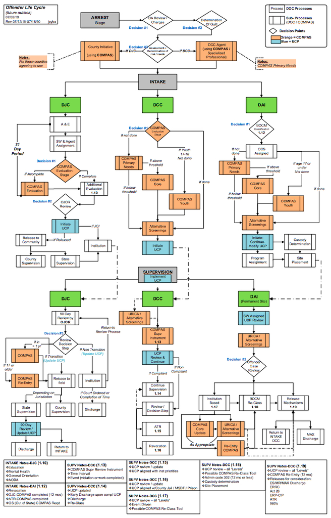

[^1]

So I’m sufficiently motivated to sink my teeth in.

Sometimes the question isn’t, “Can we predict this?”. But “Should we?”.

We do need to continuing having serious, comprehensive, nuanced conversations about the implications of predictive modeling. And we have been.

- Former U.S. Chief Data Scientist, DJ Patil, [wrote](https://medium.com/@dpatil/a-code-of-ethics-for-data-science-cda27d1fac1) a call to action among data scientists to get-ta talking about establishing a code of ethics to help guide our practice. (He actually links to Pro Publica’s “Machine Bias” article, which, admittedly, got me rolling with this post you’re reading (Mom))
- Cathy O’Neil is galvinizing conversation around the use, consequences, and risks of Big Data and maths in her book *Weapons of Math Destruction*.

[figure not shown]

  [^2]
- *Big Data*

[figure not shown]

  [^3]
- [“How Do You Regulate a Self-Improving Algorithm?”](https://www.theatlantic.com/technology/archive/2017/10/algorithms-future-of-health-care/543825/)

So again, I’m late to a party.

Commenter FastClock mentioned:

> Due process requires that in criminal proceedings the accused be able to confront and cross examine the witnesses against him.

Hear, hear! This will involve taking paint thinner to the black box that *usually* is data science/analytics/predictive modeling, and making the scientific process transparent, including educating the persons consuming, or implicated by, its results. And that’s on us: the data scientists, researchers, analysts of the world who try to make data do useful, helpful, *good* things for humanity.

Files to Pro Publica’s analysis are on Github [here](https://github.com/propublica/compas-analysis).

[^1]: Source: [Wisconsin Department of Corrections](https://doc.wi.gov/Documents/AboutDOC/Reentry/offenderlifecycle.pdf)
[^2]: Source: [Amazon](https://www.amazon.com/Weapons-Math-Destruction-Increases-Inequality/dp/0553418815)
[^3]: Source: [Amazon](https://www.amazon.com/Big-Data-Revolution-Transform-Think/dp/0544227751/ref=sr_1_3?ie=UTF8&qid=1528067799&sr=8-3&keywords=big+data&dpID=51oUcCSWb0L&preST=_SY291_BO1,204,203,200_QL40_&dpSrc=srch)